# manova

# Using MANOVA to Analyse a Banking Crisis

[Original Source](http://www.r-exercises.com/2016/08/24/using-manova-to-analyse-banking-crises/)

Try to find if there is a difference in the combination of export and bank reserves, depending on the status of banking sector (is there a crisis or not).

```r
library("MVN")
```

```r
library("heplots")
```

## Exercise 1

Is the sample size large enough for conducting MANOVA? (Tip: You should have at least 2 cases for each cell.)

1. Yes
2. No

```r
data <- read.csv("http://www.r-exercises.com/wp-content/uploads/2016/08/banking-crises-data.csv", sep=",", header=TRUE)
aggregate(.~crisis, data=data, FUN=function(x){sum(!is.na(x))}, na.action = na.pass)
```

```
##   crisis export reserves
## 1     No     67       67
## 2    Yes     12       12
```

## Exercise 2

Are there univariate and multivariate outliers?

1. There are univariate, but not multivariate outliers
2. There doesn’t exist a univariate outlier, but there are multivariate outliers
3. There exist both univariate and multivariate outliers

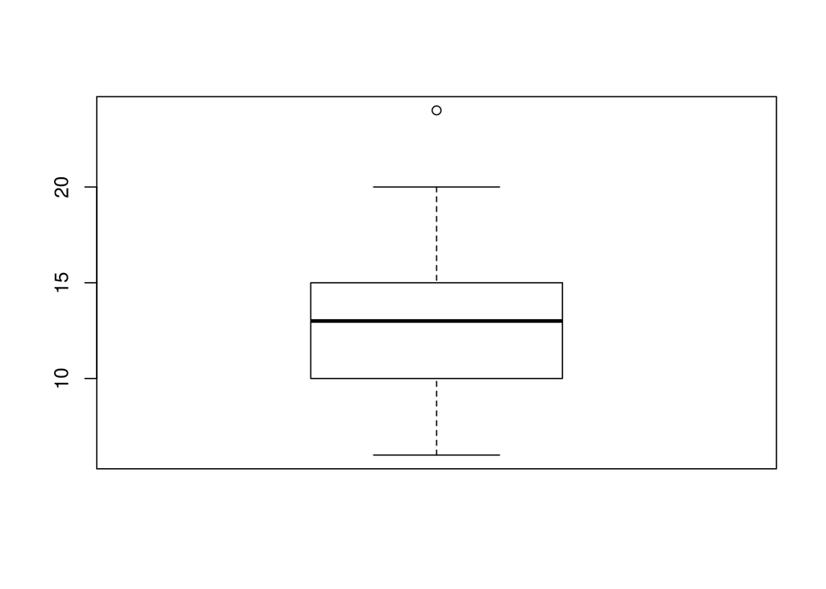

```
## [1] 24
```

```r
boxplot(data$export)$out
```

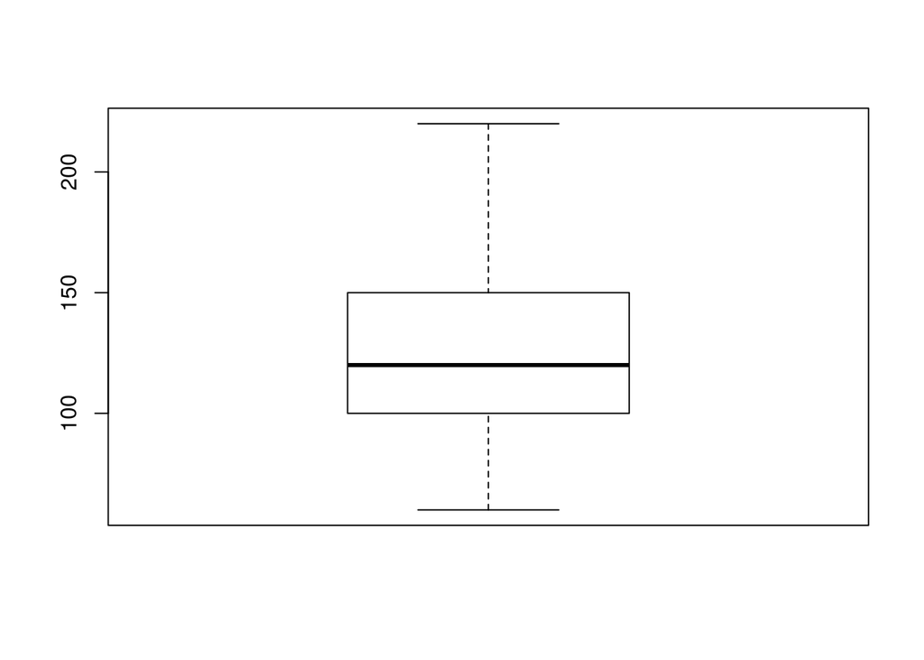

```
## numeric(0)
```

```r
boxplot(data$reserves)$out
```

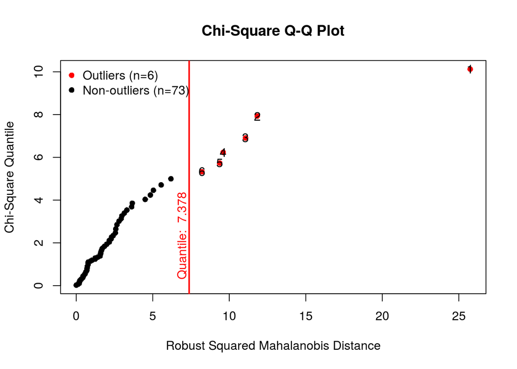

```
##   Observation Mahalanobis Distance Outlier
## 1           1               25.747    TRUE
## 2           2               11.828    TRUE
## 3           3               11.067    TRUE
## 4           4                9.605    TRUE
## 5           5                9.378    TRUE
## 6           6                8.211    TRUE
```

```r
head(mvOutlier(data[, 2:3], qqplot=TRUE)$outlier)
```

## Exercise 3

How do you estimate univariate and multivariate normality of dependent variables?

1. Both variables are univariate normal, but they are not multivariate normally distributed
2. None of the variables is univariate normal, and hence there doesn’t exist multivariate normality
3. Both variables are univariate normal and the data is multivariate normally distributed

```r
uniNorm(data[, 2:3], type="SW", desc=TRUE)
```

```
## $`Descriptive Statistics`
##           n    Mean Std.Dev Median Min Max 25th 75th  Skew Kurtosis
## export   79  12.722   3.704     13   6  24   10   15 0.180   -0.134
## reserves 79 124.177  36.290    120  60 220  100  150 0.267   -0.283
##
## $`Shapiro-Wilk's Normality Test`
##    Variable Statistic   p-value Normality
## 1  export      0.9785    0.2023    YES
## 2 reserves     0.9793    0.2278    YES
```

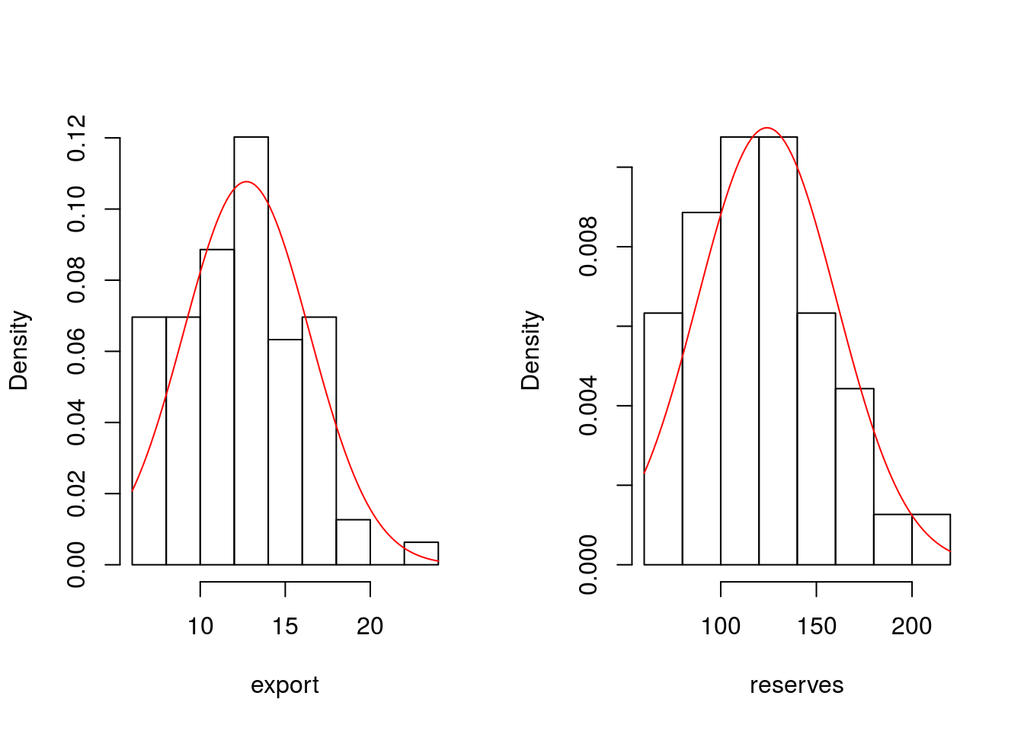

```r
uniPlot(data[, 2:3], type="histogram")
```

```r
mardiaTest(data[, 2:3], qqplot=TRUE)
```

```
##    Mardia's Multivariate Normality Test
## ---------------------------------------
##    data : data[, 2:3]
##
##    g1p            : 1.372014
##    chi.skew       : 18.06485
##    p.value.skew   : 0.0011986
##
##    g2p            : 9.37286
##    z.kurtosis     : 1.525281
##    p.value.kurt   : 0.1271889
##
##    chi.small.skew : 19.23164
##    p.value.small  : 0.0007077098
##
##    Result          : Data are not multivariate normal.
## ---------------------------------------
```

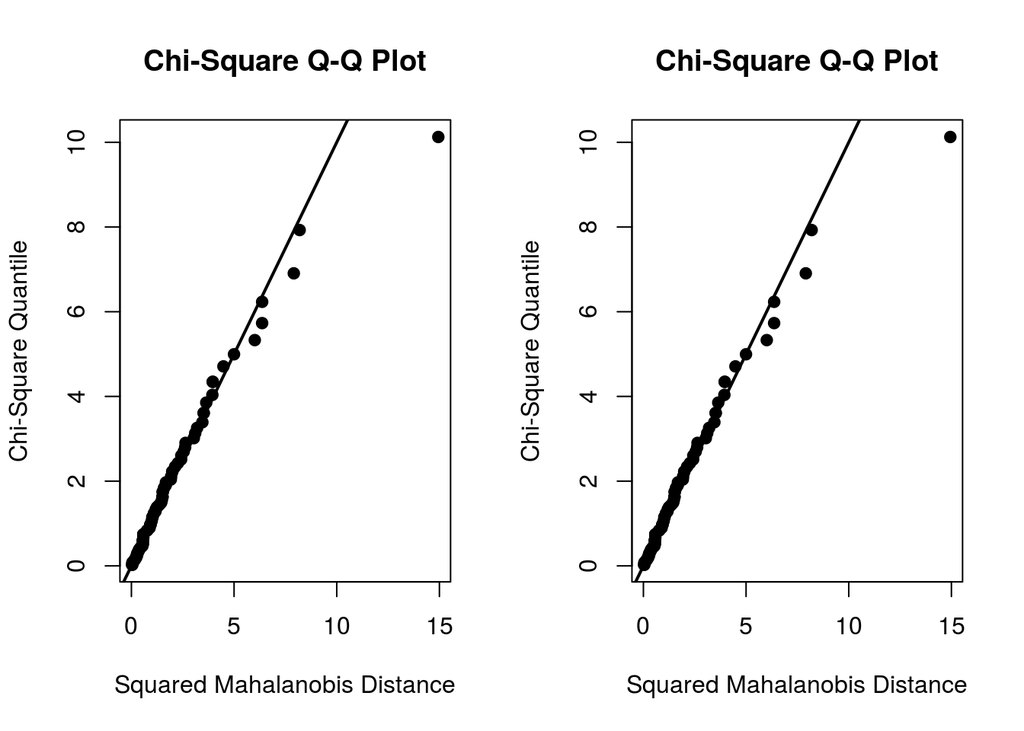

```
##   Henze-Zirkler's Multivariate Normality Test
## ---------------------------------------------
##   data : data[, 2:3]
##
##   HZ      : 0.9748434
##   p-value : 0.03951718
##
##   Result  : Data are not multivariate normal.
## ---------------------------------------------
```

```r
hzTest(data[, 2:3], qqplot=TRUE)
```

```
##   Royston's Multivariate Normality Test
## ---------------------------------------------
##   data : data[, 2:3]
##
##   H       : 3.071635
##   p-value : 0.2144106
##
##   Result  : Data are multivariate normal.
## ---------------------------------------------
```

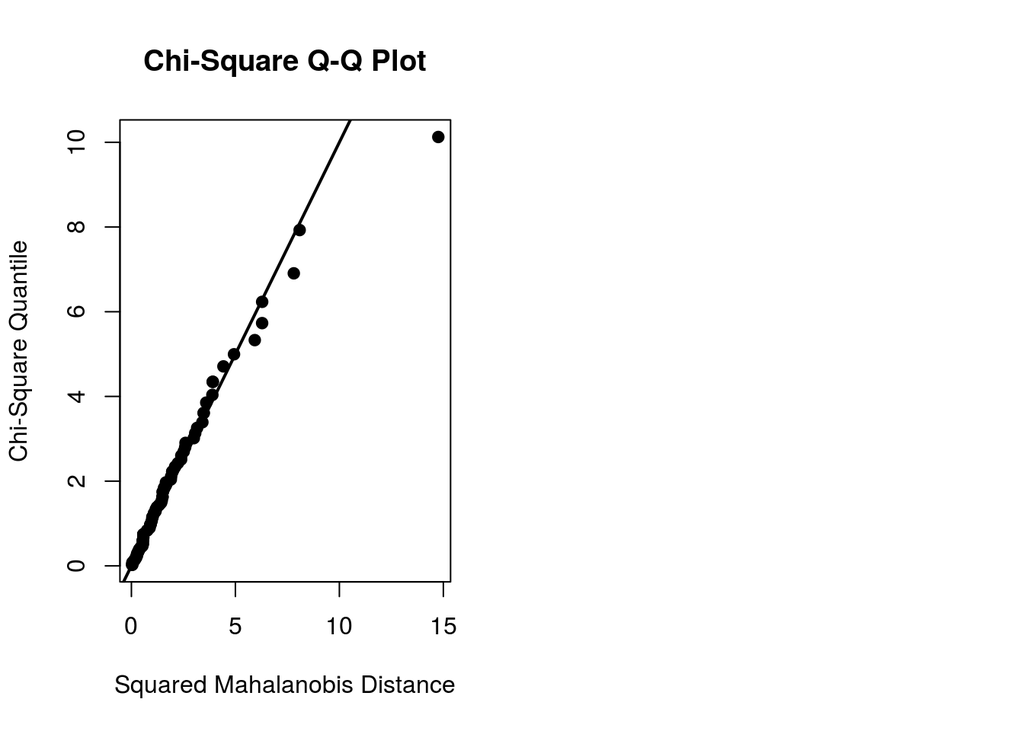

```r
roystonTest(data[, 2:3], qqplot=TRUE)
```

## Exercise 4

Using the matrix of scatter plots, check for the linearity between dependent variables export and reserves for each category of independent variable.

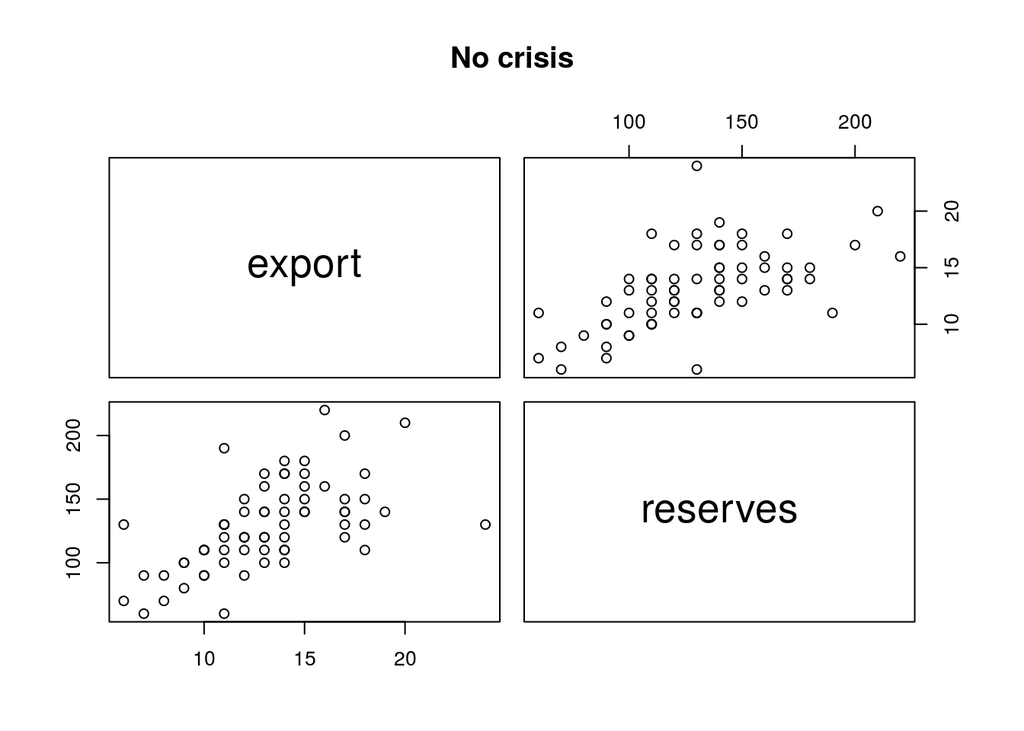

```r
pairs(data[data$crisis=="No", 2:3], main="No crisis")
```

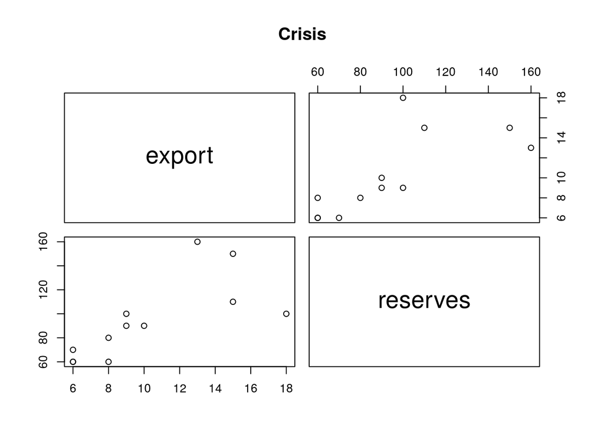

```r
pairs(data[data$crisis=="Yes", 2:3], main="Crisis")
```

## Exercise 5

Calculate the correlation between dependent variables export and reserves. Is it appropriate to justify conducting MANOVA?

1. Yes
2. No

```r
cor(data$export, data$reserves)
```

```
## [1] 0.6421562
```

## Exercise 6

Is there equality of covariances of the dependent variables export and reserves across the groups. (Tip: You should perform Box’s M test of equality of covariance matrices.)

1. Yes
2. No

```r
boxM(data[, 2:3], group=data$crisis)
```

```
##
##  Box's M-test for Homogeneity of Covariance Matrices
##
## data:  data[, 2:3]
## Chi-Sq (approx.) = 1.0465, df = 3, p-value = 0.79
```

## Exercise 7

Is there equality of variances of the dependent variables export and reserves across groups? (Tip: Use Levens’s test of error variances.)

1. Yes
2. No

```r
leveneTests(data[, 2:3], group=data$crisis, center=mean)
```

```
## Levene's Tests for Homogeneity of Variance (center = mean)
##
##          df1 df2 F value Pr(>F)
## export     1  77  0.8434 0.3613
## reserves   1  77  0.0807 0.7770
```

## Exercise 8

On the level of significance of 0.05, is there effect of banking crisis to export and banking reserves combination?

1. Yes
2. No

```r
m <- manova(cbind(data$export, data$reserves)~data$crisis)
summary(m)
```

```
##             Df  Pillai approx F num Df den Df   Pr(>F)
## data$crisis  1 0.12979   5.6677      2     76 0.005078 **
## Residuals   77
## ---
## Signif. codes:  0 '***' 0.001 '**' 0.01 '*' 0.05 '.' 0.1 ' ' 1
```

## Exercise 9

How much of the variance in the dependent variables export and reserves is explained by banking crisis?

```r
etasq(m)
```

```
##                 eta^2
## data$crisis 0.1297908
```

## Exercise 10

Does the export differ when banking sector is in the crisis compared to when banking sector is not in the crisis? What about reserves?

1. Only export differ
2. Only reserves differ
3. Both export and reserves differ
4. None of them differ

```r
summary(aov(cbind(data$export, data$reserves)~data$crisis))
```

```
##  Response 1 :
##             Df Sum Sq Mean Sq F value  Pr(>F)
## data$crisis  1  86.43  86.429  6.7671 0.01113 *
## Residuals   77 983.44  12.772
## ---
## Signif. codes:  0 '***' 0.001 '**' 0.01 '*' 0.05 '.' 0.1 ' ' 1
##
##  Response 2 :
##             Df Sum Sq Mean Sq F value   Pr(>F)
## data$crisis  1  12743 12743.3  10.905 0.001456 **
## Residuals   77  89978  1168.5
## ---
## Signif. codes:  0 '***' 0.001 '**' 0.01 '*' 0.05 '.' 0.1 ' ' 1
```